# Hello, Quarto

Author

Biostats and Modelling

Published

January 6, 2025

## 1 Introduction to Quarto

Quarto is a publishing system that allows you to create documents, presentations, websites, and more using Markdown syntax and additional tools.

## 2 Header Levels

Quarto supports multiple header levels to create a hierarchical structure in your document. For example:

- Level 1 header: `# Header`
- Level 2 header: `## Subheader`
- Level 3 header: `### Sub-subheader`

### 2.1 Nested Headers

Using headers, you can create nested sections to structure your document in a clear and organized way.

## 3 Inline Text Formatting

You can format your text inline to add emphasis or other styling options.

- **Bold text**: `**bold**`
- *Italic text*: `*italic*`
- Inline `code`: `` `code` ``
- Underline: `[underline]{.underline}`

> Blockquotes can be used to highlight important information or quotes by adding `>` at the beginning of a line.

## 4 Lists

Quarto supports both ordered and unordered lists.

### 4.1 Unordered List

To create an unordered list, use an asterisk `*` before each item:

- First item
- Second item
- Third item

### 4.2 Ordered List

To create an ordered list, use numbers before each item:

1. First item
2. Second item
3. Third item

## 5 Links and images

http://example.com

[linked phrase](http://example.com)

## 6 Tables

| First Header | Second Header |
| --- | --- |
| Content Cell | Content Cell |
| Content Cell | Content Cell |

## 7 Code block

Quarto also supports code blocks, making it easy to include and execute code within your document. Here’s an example of a code block to create a simple plot using R:

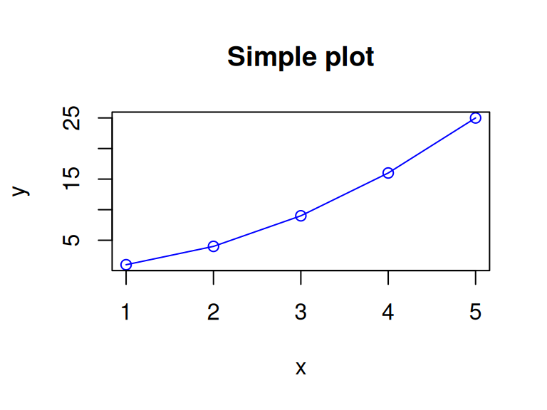

```r
x <- c(1, 2, 3, 4, 5)
y <- c(1, 4, 9, 16, 25)

plot(x, y, type = "o", col = "blue", main = "Simple plot", xlab = "x", ylab = "y")
```

## 8 Footnotes

Footnotes can be added inline to provide additional information or references. Here’s an example of a footnote in Quarto: [^1]

## Footnotes

[^1]: This is an example footnote.